# Course_Project_Part_1

suveyda

January 31, 2017

# Course Project Part 1

## Statistical Inference by Johns Hopkins University

### Introduction

In this part, using simulation, we will illustrate the properties of the distribution of the mean of 40 exponentials. As part of the project, we will investigate the exponential distribution in R and compare sample mean/sample variance and theoretical mean/theoretical variance of the distribution respectivelly. In addition, we will also investigate the distribution and check whether the the Central Limit Theorem holds or not.

The exponential distribution can be simulated in R with rexp(n, lambda) where lambda is the rate parameter. The mean of exponential distribution is 1/lambda and the standard deviation is also 1/lambda. We will set lambda = 0.2 for all of the simulations, and investigate the distribution of averages of 40 exponentials through one thousand simulations.

### Simulations

Let’s first create the variables for the simulation:

```r
n <- 40
lambda <- 0.2
num.of.sim <- 1000
```

Before running the simulation, we set the seed to 3 so that we will get same results everytime we run the R code:

```r
set.seed(3)
```

Now we can create a thousand simulated averages of 40 exponentials with lambda equal to 0.2. We keep all the generated simulations in a matrix and then generate the mean of each simulation below:

```r
sim.data <- matrix(data = rexp(n * num.of.sim, lambda), nrow = num.of.sim, ncol = n)
sim.data.mean <- data.frame(means=apply(sim.data, 1, mean))
```

### Sample Mean versus Theoretical Mean

Now let’s find the sample mean and compare it to the theoretical mean of the distribution. As mentioned above, the mean of exponential distribution is 1/lambda. So, we first find the sample mean and theoretical mean:

```r
sample.mean <- mean(sim.data.mean$means)
sample.mean
```

```
## [1] 4.98662
```

```r
theoretical.mean <- 1.0/lambda
theoretical.mean
```

```
## [1] 5
```

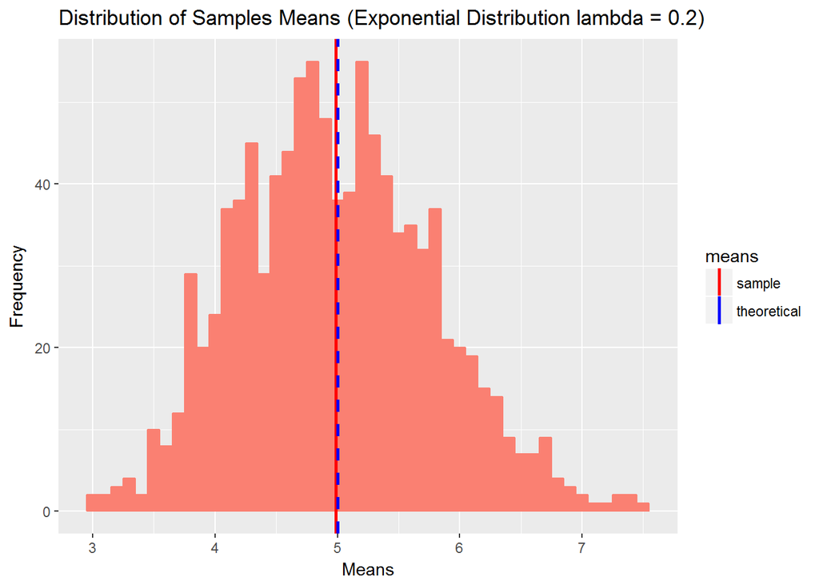

```r
sample.mean.plot <- ggplot(data = sim.data.mean, aes(x = means)) + geom_histogram(binwidth=0.1, fill = "salmon", color = "salmon") + geom_vline(aes(xintercept = sample.mean, color = "sample"), linetype=1, size = 1, show.legend=TRUE) + geom_vline(aes(xintercept = theoretical.mean, color = "theoretical"), linetype=2, size = 1, show.legend=TRUE) + scale_color_manual(name = "means", values = c(sample = "red", theoretical = "blue")) + ggtitle("Distribution of Samples Means (Exponential Distribution lambda = 0.2)") + xlab("Means") + ylab("Frequency")
sample.mean.plot
```

In the above plot, you can see the distribution of averages of 40 exponentials through one thousand simulations. In the plot, the blue line represents the theoretical mean while red line represents the sample mean obtained from the simulation. As you can see, mean values are very close to each other.

### Sample Variance versus Theoretical Variance

Now let’s find the sample variance and compare it to the theoretical variance of the distribution. As mentioned above, the standard deviation is 1/lambda. Futhermore, the average of a random sample from a population is itself a random variable with variance (1/lambda)^2 / n. So, let’s first find the sample variance and theoretical variance:

```r
sample.variance <- var(sim.data.mean$means)
sample.variance
```

```
## [1] 0.6257575
```

```r
theoretical.variance <- ((1.0/lambda)**2)/n
theoretical.variance
```

```
## [1] 0.625
```

As you can see, sample variance and theoretical variance are also close.

### Distribution

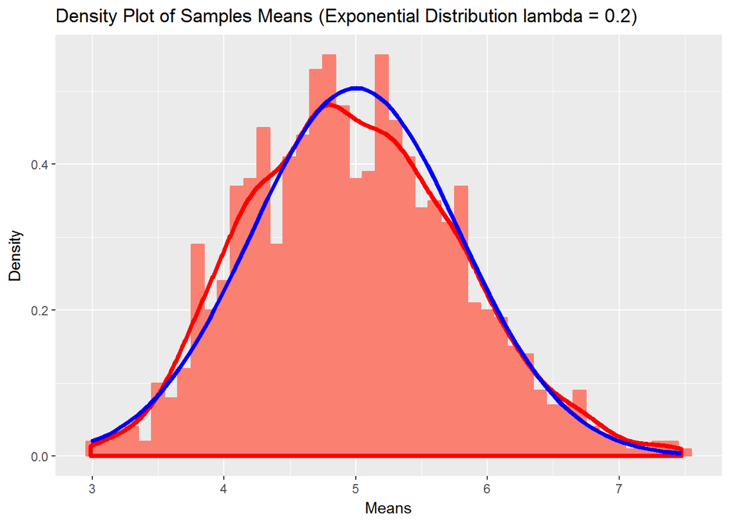

```r
distribution.plot <- ggplot(data = sim.data.mean, aes(x = means)) + geom_histogram(binwidth=0.1, aes(y = ..density..), fill = "salmon", color = "salmon") + geom_density(color = "red", size = 1.5) + stat_function(fun = dnorm, args = list(mean = theoretical.mean, sd = sd(sim.data.mean$means)), color = "blue", geom = "line", size = 1.5) + ggtitle("Density Plot of Samples Means (Exponential Distribution lambda = 0.2)") + xlab("Means") + ylab("Density")
distribution.plot
```

In addition, we can investigate whether the distribution resembles a normal distribution through a Q-Q plot. A Q-Q plot is a scatterplot created by plotting two sets of quantiles against one another. If both sets of quantiles came from the same distribution, we should see the points forming a line that’s roughly straight. According to the below plot, points seem to fall on a straight line which suggests that distribution is approximately normal.

This is an expected result due to the Central Limit Theorem which states that the arithmetic mean of a sufficiently large number of iterates of independent random variables will be approximately normally distributed, regardless of the underlying distribution. So even if the original variables themselves are not normally distributed, the averages of samples should follow a normal distribution, and as the number of samples increase, the density distribution will get closer to the normal distribution’s bell curve.

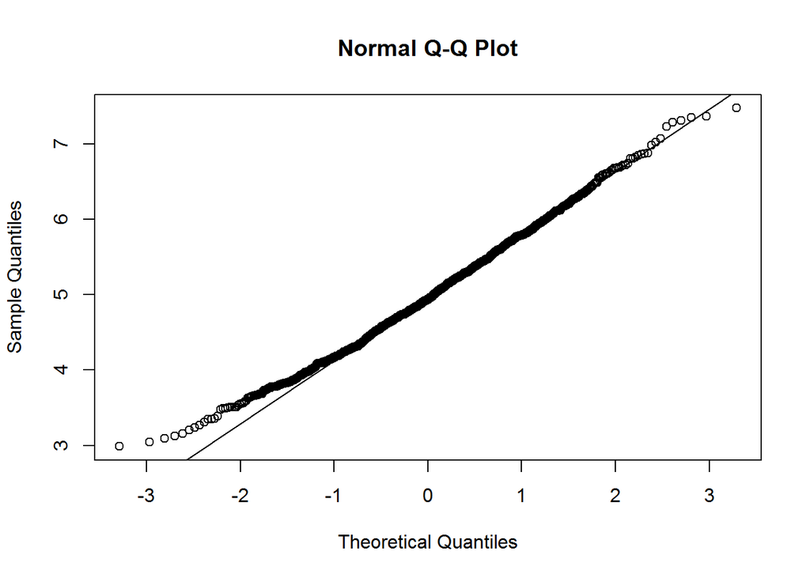

```r
qqnorm(sim.data.mean$means);
qqline(sim.data.mean$means)
```